# Imports

# Data Transforms and Exploration

- There is overall little EDA and cleaning to do here. This was also missing from the assignment requirements section but I will assume its needed.
- Check for 300 images in training set.
- Check for 7038 images in testing set.
- Verify dimensions on all photos.
- Compare RGB intensity between training and testing set.

```python
# image properties
def check_image_properties(directory):
    file_count = 0
    image_shapes = []
    for file_name in os.listdir(directory):
        file_path = os.path.join(directory, file_name)
        try:
            img = Image.open(file_path)
            image_shapes.append(img.size)
            file_count += 1
        except Exception as e:
            print(f"Error reading file {file_name}: {e}")
    return file_count, set(image_shapes)

# Monet paintings
monet_count, monet_shapes = check_image_properties(monet_dir)
print(f"Monet paintings: {monet_count} images, Dimensions: {monet_shapes}")

# Photos
photo_count, photo_shapes = check_image_properties(photo_dir)
print(f"Photos: {photo_count} images, Dimensions: {photo_shapes}")
```

```
Monet paintings: 300 images, Dimensions: {(256, 256)}
Photos: 7038 images, Dimensions: {(256, 256)}
```

[figure not shown]

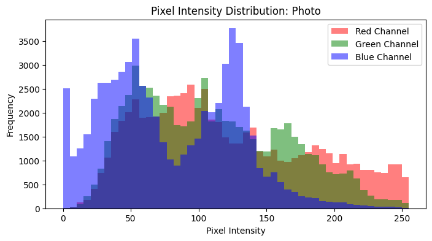

```python
# Pixel intensity histogram
def plot_pixel_histogram(image_path, title):
    img = Image.open(image_path)
    img_array = np.array(img)
    plt.figure(figsize=(8, 4))
    for i, color in enumerate(['Red', 'Green', 'Blue']):
        plt.hist(img_array[..., i].flatten(), bins=50, alpha=0.5, label=f'{color} Channel', color=color.lower())
    plt.title(title)
    plt.xlabel('Pixel Intensity')
    plt.ylabel('Frequency')
    plt.legend()
    plt.show()

# Plot Monet
sample_monet = os.listdir(monet_dir)[0]
plot_pixel_histogram(os.path.join(monet_dir, sample_monet), "Pixel Intensity Distribution: Monet Painting")

# Plot General
sample_photo = os.listdir(photo_dir)[0]
plot_pixel_histogram(os.path.join(photo_dir, sample_photo), "Pixel Intensity Distribution: Photo")
```

- Monet bright vibrant style can be seen in the pixel intensity histograms here

# Model Architecture

For this model I will be utilizing latent vector as input and generate a 256 x 256 image. In theory the image should look progressively more and more like a Monet painting through upsampling. Each upsampling layer that occurs increases complexity and provides space for the model to apply its learned “Monetification”. Each upsampling layer cuts the number of filters to counter balance the added complexity of the upsampling. This helps with model building time, overfitting and memory usage.

- Input Layer
  - Takes in a latent vector of a given size which serves as the seed to create new images
- Dense Layer
  - Changes the latent vector into a multi dimensional array which can then be convolutionally processed
  - The output is 16 x 16
  - The activation (LeakyReLu) provides non-linearity
- Upsampling Layers
  - Spatial dimensions double each layer until 256x256 is reached form 16x16
  - Filter number decreases
- I will use random search for hyperparameter tuning to optimize model performance. The values tested will be:
  - Learning Rate: [0.00005, 0.0001, 0.00015, 0.0002, 0.00025, 0.0003, 0.00035, 0.0004, 0.00045, 0.0005]
  - Beta 1: [0.4, 0.5, 0.6, 0.7, 0.8, 0.9]
  - Latent Dimension: [50, 100, 150, 200, 250, 300]
  - Generator Filters: [64, 128, 256, 512]
  - Discriminator Filters: [64, 128, 256, 512]
  - Dropout Rate: [0.2, 0.3, 0.4, 0.5]

# Model Building

```python
def build_generator(latent_dim, filters):
    model = Sequential()

    # Input layer
    model.add(Input(shape=(latent_dim,)))

    # First Dense layer
    model.add(Dense(filters * 16 * 16))
    model.add(LeakyReLU(0.2))
    model.add(Reshape((16, 16, filters)))

    # Upsampling to 32x32
    model.add(Conv2DTranspose(filters // 2, kernel_size=4, strides=2, padding='same'))
    model.add(LeakyReLU(0.2))
    model.add(BatchNormalization())

    # Upsample to 64x64
    model.add(Conv2DTranspose(filters // 4, kernel_size=4, strides=2, padding='same'))
    model.add(LeakyReLU(0.2))
    model.add(BatchNormalization())

    # Upsample to 128x128
    model.add(Conv2DTranspose(filters // 8, kernel_size=4, strides=2, padding='same'))
    model.add(LeakyReLU(0.2))
    model.add(BatchNormalization())

    # Upsample to 256x256 and output layer
    model.add(Conv2DTranspose(3, kernel_size=4, strides=2, padding='same', activation='tanh'))

    return model
```

```python
# Hyperparameter grid
param_grid = {
    "learning_rate": np.linspace(0.00005, 0.0005, 10).tolist(),
    "beta_1": np.linspace(0.4, 0.9, 6).tolist(),
    "latent_dim": [50, 100, 150, 200, 250, 300],
    "gen_filters": [64, 128, 256, 512],
    "disc_filters": [64, 128, 256, 512],
    "dropout_rate": np.linspace(0.2, 0.5, 4).tolist(),
}
```

```python
def random_search(param_grid, num_trials=20):
    best_params = None
    best_loss = float('inf')
    for trial in range(num_trials):
        # Randomly sample hyperparameters
        params = {key: random.choice(values) for key, values in param_grid.items()}
        print(f"\nTrial {trial + 1}/{num_trials}: Testing parameters {params}")

        # Extract hyperparameters
        latent_dim = params["latent_dim"]
        gen_filters = params["gen_filters"]
        disc_filters = params["disc_filters"]
        dropout_rate = params["dropout_rate"]
        learning_rate = params["learning_rate"]
        beta_1 = params["beta_1"]

        # Build models with these values
        generator = build_generator(latent_dim, gen_filters)
        discriminator = build_discriminator(disc_filters, dropout_rate)

        # Compile discriminator
        discriminator.compile(
            loss='binary_crossentropy',
            optimizer=Adam(learning_rate=learning_rate, beta_1=beta_1)
        )

        # Build GAN
        discriminator.trainable = False
        gan_input = Input(shape=(latent_dim,))
        gan_output = discriminator(generator(gan_input))
        gan = Model(gan_input, gan_output)
        gan.compile(
            loss='binary_crossentropy',
            optimizer=Adam(learning_rate=learning_rate, beta_1=beta_1)
        )

        # Evaluate
        noise = np.random.normal(0, 1, (10, latent_dim))
        labels = np.ones((10, 1))
        loss = gan.evaluate(noise, labels, verbose=0)

        print(f"Loss: {loss:.4f}")

        # Update best parameters if current loss is lower
        if loss < best_loss:
            best_loss = loss
            best_params = params

    print(f"\nBest parameters: {best_params}, Best loss: {best_loss:.4f}")
    return best_params
```

```python
def build_discriminator(filters, dropout_rate, input_shape=(256, 256, 3)):
    model = Sequential()

    # Input layer
    model.add(Input(shape=input_shape))

    # First Conv layer
    model.add(Conv2D(filters, kernel_size=4, strides=2, padding='same'))
    model.add(LeakyReLU(0.2))

    # Second Conv layer
    model.add(Conv2D(filters * 2, kernel_size=4, strides=2, padding='same'))
    model.add(LeakyReLU(0.2))
    model.add(Dropout(dropout_rate))

    # Third Conv layer
    model.add(Conv2D(filters * 4, kernel_size=4, strides=2, padding='same'))
    model.add(LeakyReLU(0.2))
    model.add(Dropout(dropout_rate))

    # Flatten and output layer
    model.add(Flatten())
    model.add(Dense(1, activation='sigmoid'))

    return model
```

```python
# Trial attempts
num_trials = 20

# Random Search
best_params = random_search(param_grid, num_trials=num_trials)
```

```
Trial 1/20: Testing parameters {'learning_rate': 0.00019999999999999998, 'beta_1': 0.7000000000000001, 'latent_dim': 50, 'gen_filters': 512, 'disc_filters': 512, 'dropout_rate': 0.3}
Loss: 0.6931

Trial 2/20: Testing parameters {'learning_rate': 0.00039999999999999996, 'beta_1': 0.4, 'latent_dim': 250, 'gen_filters': 512, 'disc_filters': 256, 'dropout_rate': 0.2}
Loss: 0.6932

Trial 3/20: Testing parameters {'learning_rate': 0.0005, 'beta_1': 0.5, 'latent_dim': 300, 'gen_filters': 512, 'disc_filters': 64, 'dropout_rate': 0.2}
Loss: 0.6931

Trial 4/20: Testing parameters {'learning_rate': 0.0005, 'beta_1': 0.7000000000000001, 'latent_dim': 100, 'gen_filters': 128, 'disc_filters': 256, 'dropout_rate': 0.5}
Loss: 0.6932

Trial 5/20: Testing parameters {'learning_rate': 0.00045, 'beta_1': 0.5, 'latent_dim': 300, 'gen_filters': 128, 'disc_filters': 128, 'dropout_rate': 0.3}
Loss: 0.6932

Trial 6/20: Testing parameters {'learning_rate': 5e-05, 'beta_1': 0.8, 'latent_dim': 150, 'gen_filters': 64, 'disc_filters': 64, 'dropout_rate': 0.4}
Loss: 0.6933

Trial 7/20: Testing parameters {'learning_rate': 0.00045, 'beta_1': 0.4, 'latent_dim': 300, 'gen_filters': 256, 'disc_filters': 512, 'dropout_rate': 0.2}
Loss: 0.6932

Trial 8/20: Testing parameters {'learning_rate': 0.00039999999999999996, 'beta_1': 0.9, 'latent_dim': 50, 'gen_filters': 256, 'disc_filters': 256, 'dropout_rate': 0.3}
Loss: 0.6931

Trial 9/20: Testing parameters {'learning_rate': 0.00045, 'beta_1': 0.8, 'latent_dim': 50, 'gen_filters': 256, 'disc_filters': 256, 'dropout_rate': 0.2}
Loss: 0.6932

Trial 10/20: Testing parameters {'learning_rate': 0.00035, 'beta_1': 0.9, 'latent_dim': 300, 'gen_filters': 256, 'disc_filters': 64, 'dropout_rate': 0.4}
Loss: 0.6933

Trial 11/20: Testing parameters {'learning_rate': 0.00019999999999999998, 'beta_1': 0.7000000000000001, 'latent_dim': 250, 'gen_filters': 128, 'disc_filters': 128, 'dropout_rate': 0.4}
Loss: 0.6931

Trial 12/20: Testing parameters {'learning_rate': 0.00025, 'beta_1': 0.4, 'latent_dim': 150, 'gen_filters': 256, 'disc_filters': 512, 'dropout_rate': 0.3}
Loss: 0.6931

Trial 13/20: Testing parameters {'learning_rate': 0.00035, 'beta_1': 0.7000000000000001, 'latent_dim': 250, 'gen_filters': 64, 'disc_filters': 64, 'dropout_rate': 0.4}
Loss: 0.6935

Trial 14/20: Testing parameters {'learning_rate': 9.999999999999999e-05, 'beta_1': 0.6000000000000001, 'latent_dim': 250, 'gen_filters': 256, 'disc_filters': 64, 'dropout_rate': 0.2}
Loss: 0.6932

Trial 15/20: Testing parameters {'learning_rate': 0.00045, 'beta_1': 0.7000000000000001, 'latent_dim': 200, 'gen_filters': 64, 'disc_filters': 256, 'dropout_rate': 0.2}
Loss: 0.6931

Trial 16/20: Testing parameters {'learning_rate': 5e-05, 'beta_1': 0.5, 'latent_dim': 150, 'gen_filters': 512, 'disc_filters': 512, 'dropout_rate': 0.4}
Loss: 0.6932

Trial 17/20: Testing parameters {'learning_rate': 0.0005, 'beta_1': 0.5, 'latent_dim': 200, 'gen_filters': 256, 'disc_filters': 512, 'dropout_rate': 0.2}
Loss: 0.6932

Trial 18/20: Testing parameters {'learning_rate': 5e-05, 'beta_1': 0.8, 'latent_dim': 250, 'gen_filters': 512, 'disc_filters': 512, 'dropout_rate': 0.2}
Loss: 0.6931

Trial 19/20: Testing parameters {'learning_rate': 9.999999999999999e-05, 'beta_1': 0.5, 'latent_dim': 150, 'gen_filters': 64, 'disc_filters': 512, 'dropout_rate': 0.4}
Loss: 0.6931

Trial 20/20: Testing parameters {'learning_rate': 0.00035, 'beta_1': 0.5, 'latent_dim': 250, 'gen_filters': 128, 'disc_filters': 512, 'dropout_rate': 0.5}
Loss: 0.6931

Best parameters: {'learning_rate': 0.00019999999999999998, 'beta_1': 0.7000000000000001, 'latent_dim': 250, 'gen_filters': 128, 'disc_filters': 128, 'dropout_rate': 0.4}, Best loss: 0.6931
```